# Ladder rung analysis

Ruslan Rust

8/25/2021

# (1) Required Packages, Initialization, Customized Functions,

```r
# Download required packages
packages <-  c("plyr","ggplot2","RColorBrewer","scales", "gridExtra", "FSA", "tidyr", "mise", "stringr", "plotrix", "ggpmisc", "tibble", "forcats", "data.table", "dplyr", "PupillometryR", "gghalves")
invisible(lapply(packages, library, character.only = TRUE))

# Clearing all previous data, plots
mise()
```

```r
# Function
median_se <- function(x) {
  x <- na.omit(x)
  se <- sqrt(var(x) / length(x))
  med <- median(x)
  ggplot2:::new_data_frame(list(y = med,
                                ymin = med - se,
                                ymax = med + se),
                           n = 1)
}
```

# (2) Get Raw Data of files we would like to analyse

```r
files <- list.files(path = "Raw Files/Raw Ladder /", pattern = "*.csv", full.names = T)
glimpse(files)
```

```
##  chr [1:11] "Raw Files/Raw Ladder //0days_Mouse_ID1.csv" ...
```

```r
data <- sapply(files, read.table, simplify=F, skip = 2, sep =",", header =T)
data <- do.call(rbind.data.frame, data)

# Get correct names
data_header <- read.table(paste("Raw Files/Raw Ladder /0days_Mouse_ID1.csv", sep = ""), sep =",", header =T)
header_1 <- data.frame(sapply(data_header[1,], as.character), stringsAsFactors=FALSE)
header_2 <- data.frame(sapply(data_header[2,], as.character), stringsAsFactors=FALSE)

# Add correct names to dataframe df
names(data) <- paste(header_1[,1],header_2[,1],sep = "_")
data <- data %>% rownames_to_column("name")  %>%
  select(-name, everything())

# Create from a wide data frame, "data"  a long data frame "long_data" in the correct structure: time, x_corr, y_corr, likelihood, parameter
long_data <- NULL
for(i in 1:((dim(data)[2] - 1) / 3)){
  long_data <- rbind(long_data,data.frame(time = data[,1], x_corr = data[,3*i-1], y_corr = data[,3*i], likelyhood = data[,3*i+1] , parameter = strsplit(paste(names(data)[3*i-1]),"_")[[1]][1]))
}


# Rename columns and add to long_data (you can add further categories like Video_id, group_id dependent on your experimental set-up)
day <- as.factor(sub(".*/ *(.*?) *_Mouse.*", "\\1", data[,ncol(data)]))
mouse <- as.factor(sub(".*Mouse_ *(.*?) *.csv.*", "\\1", data[,ncol(data)]))
full_id <- as.factor(sub(".*/ *(.*?) *.csv.*", "\\1", data[,ncol(data)]))

long_data <- cbind(long_data, mouse, day, full_id)
#head(long_data)



# Assign three videos by symbol l, d, r
long_data <- long_data %>% mutate(side = case_when(
  startsWith(as.character(long_data$parameter), "l" ) ~ "left",
  startsWith(as.character(long_data$parameter), "d" ) ~ "down",
  startsWith(as.character(long_data$parameter), "r" ) ~ "right"))
```

# (3) Quality control

First, let’s identify the ratio of data that has the likelyhood above 0.95 or 95%. We expect to get values close to 90-100%. We look here at every single video recorded from every mouse.

```r
summary_of_reliability <- long_data %>%
  group_by(mouse, side, day, full_id) %>%
  mutate(confident= ifelse(likelyhood>0.95, "confident", "non-confident")) %>% # distinguish between confident and non-confident label
  summarise(success = sum(confident == "confident"),
            failed = sum(confident == "non-confident"))%>%
  group_by(full_id, day,  mouse) %>%
  summarise(success = median(success), failed = median(failed)) %>%
  mutate(ratio = success/(success+failed)*100) %>%
  gather(state, value, success:failed ) %>%
  mutate(state_new = ifelse(state =="success", paste(full_id, state), "nosuccess")) %>%
  mutate(state_new = factor(state_new))

summary_of_reliability$state_new <- fct_relevel(summary_of_reliability$state_new, "nosuccess", after = 0)
```

(3.1) Bar plot for overview of every video of every mouse

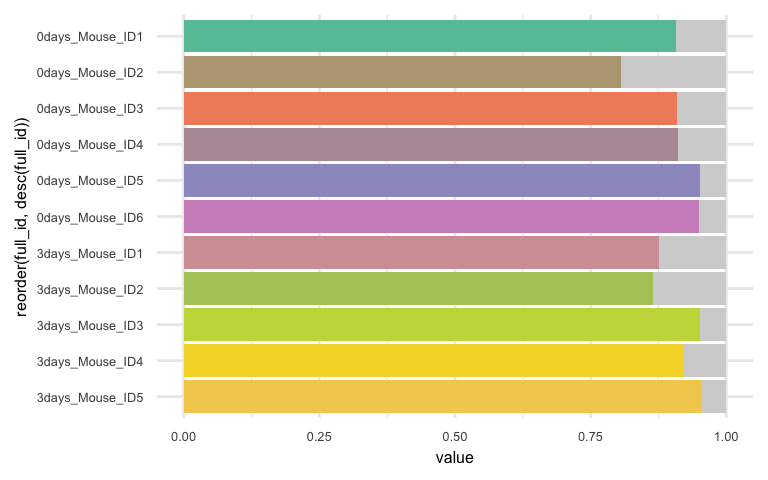

```r
# # Set Colors
mycolors <- c("lightgrey",colorRampPalette(brewer.pal(7, "Set2"))(12)) # grey = fail; colors = success


PLOT_bar_all_videos <- ggplot(summary_of_reliability, aes(x=reorder(full_id, desc(full_id)), y = value, fill =state_new))+
  geom_bar(position = "fill", stat = "identity")+
  coord_flip()+
  theme_minimal()+
  scale_fill_manual(values=mycolors)+
  theme(text = element_text(size=6))+
  theme(legend.position = "none")
PLOT_bar_all_videos
```

(3.2) Circular plot for every Video

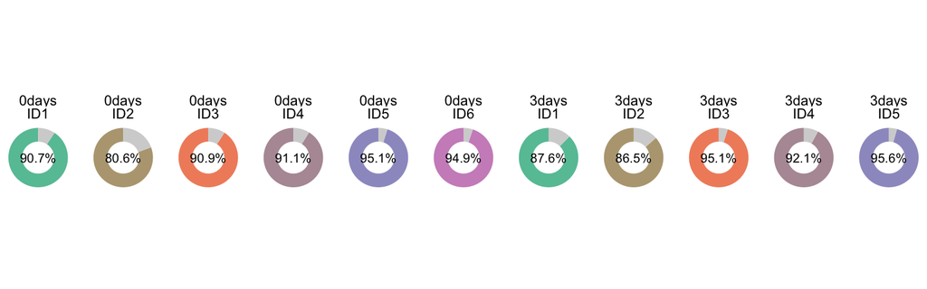

```r
# Code

# # Set Colors
mycolors2 <- colorRampPalette(brewer.pal(7, "Set2"))(12)

summary_of_reliability2  <- summary_of_reliability %>%
mutate(state_new = ifelse(state =="success", paste(mouse, state), NA))

# Plot
PLOT_Donut_Summary_Validation <- ggplot(summary_of_reliability2, aes(x=2, y = value, fill =state_new))+
  facet_wrap(day~mouse, nrow=1)+
  geom_bar(position = "fill", stat = "identity")+
  geom_text(size =2.8, mapping = aes(x = 0.5, y = 0, label = ifelse(state =="success", paste(round(ratio,digits =1), "%", sep = "") , "")))+
  xlim(0.5, 2.5) +
  coord_polar(theta='y')+
 scale_color_manual(values=mycolors2, na.value="lightgrey")+
 scale_fill_manual(values=mycolors2, na.value="lightgrey")+
  theme_void()+
  theme(plot.margin = unit(c(0, 0, 0, 0), "cm"))+
  theme(legend.position = "none")
PLOT_Donut_Summary_Validation
```

# (4) Clean data sets

Exclude all unreliable data points and all data points outside of the mouse range

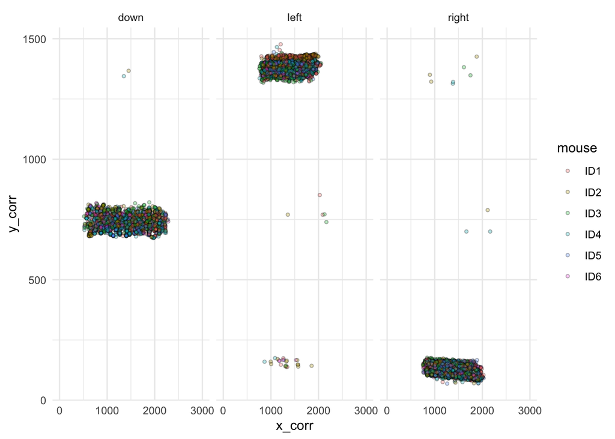

```r
# Where are the data points located on the x and y axis in each frame?

# Make a sample plot, for fast processing
long_data_sample <- sample_n(long_data, 10000)

PLOT_control_for_outliers_before <- ggplot(long_data_sample, aes(x=x_corr, y=y_corr))+
  geom_jitter(aes(fill = mouse), width=0.4, alpha=0.3, pch=21,size=1)+
  scale_x_continuous(limits = c(0, 3000))+
 facet_grid(.~side, scales = "free")+
  theme_minimal()
PLOT_control_for_outliers_before
```

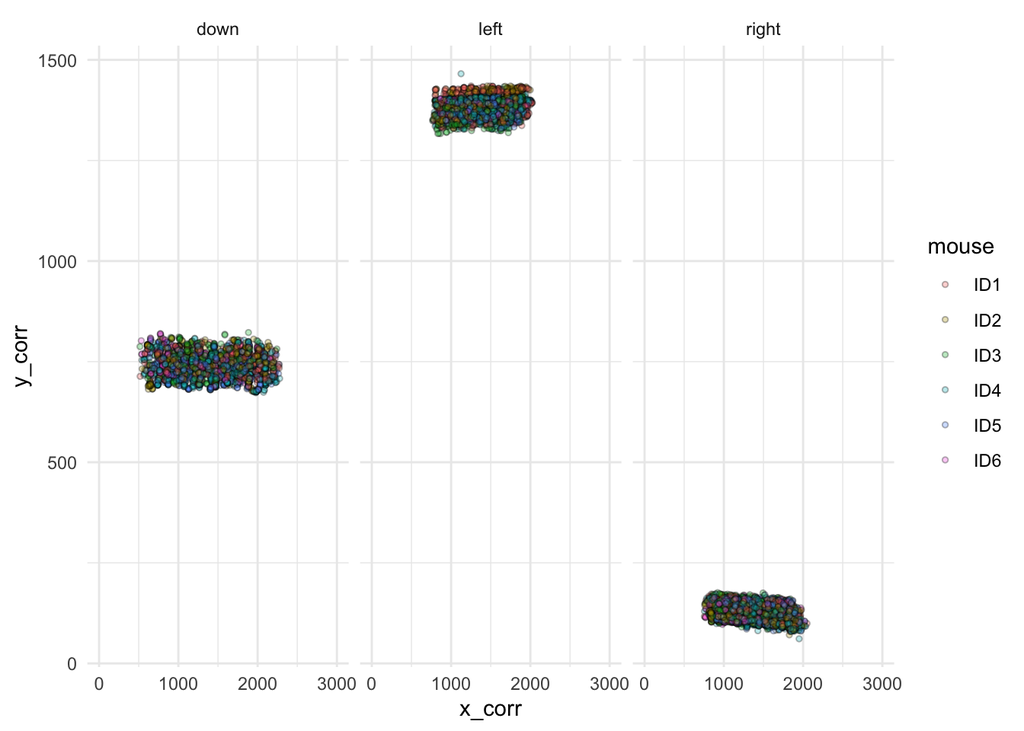

```r
# Clean the data
long_data_clean <- long_data %>%
  filter(likelyhood > 0.95) %>% #  this is the most important filter to exclude unreliable data
  filter(side =="right" & y_corr < 250 &    between(x_corr, 300, 2100) |  # Here we also exclude values that are too far away from mouse reach
         side == "left" & y_corr > 1250 &  between(x_corr, 300, 2100) |
         side == "down" & between(y_corr, 500, 1000) &between(x_corr, 250, 2500) )


long_data_clean_sample <- sample_n(long_data_clean, 10000)

PLOT_control_for_outliers_after <- ggplot(long_data_clean_sample, aes(x=x_corr, y=y_corr))+
  geom_jitter(aes(fill = mouse), width=0.4, alpha=0.3, pch=21,size=1)+
  scale_x_continuous(limits = c(0, 3000))+
 # scale_y_continuous(limits = c(1700, -100), trans="reverse")+
  facet_grid(.~side, scales = "free")+
  theme_minimal()
PLOT_control_for_outliers_after
```

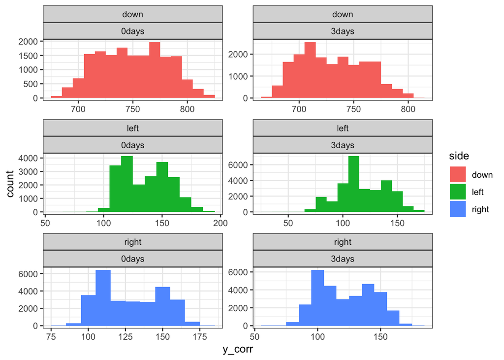

```r
# flip the left video upside down
long_data_clean2 <- long_data_clean %>%
    mutate(y_corr2 = ifelse(side == "left", y_corr*(-1)+1506, y_corr)) %>% # flip the left video upside down
    select(-y_corr) %>%
    dplyr::rename(y_corr = y_corr2)


# Distribution of x and y values at the different days
PLOT_Overview_Distribution_Y <- ggplot(long_data_clean2, aes(y_corr, fill= side)) +
  geom_histogram(binwidth= 10)+
  facet_wrap(side~day, scales = "free", nrow=3)+
  theme_bw()
PLOT_Overview_Distribution_Y
```

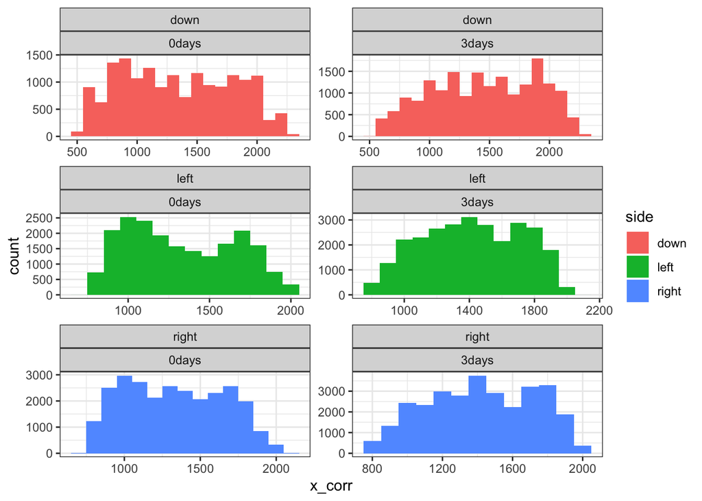

```r
PLOT_Overview_Distribution_X <- ggplot(long_data_clean2, aes(x_corr, fill= side)) +
  geom_histogram(binwidth= 100)+
  facet_wrap(side~day, scales = "free", nrow=3)+
  theme_bw()
PLOT_Overview_Distribution_X
```

(4.1) Overview of Typical Mouse Profile. Each frame of a video is normalized to the left hip (left perspecitve), right hip (right perspective), center back (down perspective)

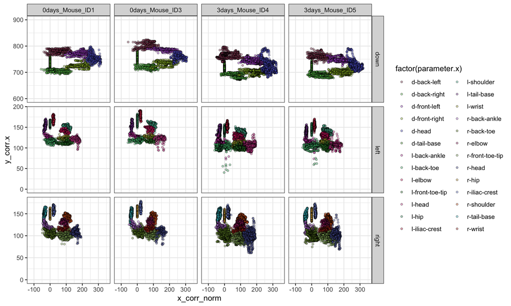

```r
# normalize to l-hip, r-hip, d-tail-base
df_norm <- long_data_clean2 %>% full_join(filter(long_data_clean, parameter %in% c("r-hip", "d-tail-base", "l-hip")), by = c("full_id", "mouse", "time", "day", "side")) %>%
  select(mouse, full_id, time, side, day, x_corr.x, y_corr.x, likelyhood.x, parameter.x, x_corr.y, y_corr.y, likelyhood.y, parameter.y) %>%
  mutate(x_corr_norm = x_corr.x- x_corr.y) %>%  # New variable y_corr_norm which gives the normalized x-coordinate to the hip
 filter(full_id %in% c("0days_Mouse_ID1","0days_Mouse_ID3","3days_Mouse_ID5", "3days_Mouse_ID4"))  # example videos



# We build a  helper function to have control over the range otherwise the facette range may be not 100% symmetrical
df_norm<- data.table(df_norm)
df_norm[side == "right",y_min := 0]
df_norm[side == "right",y_max := 150]
df_norm[side == "left",y_min := 0]
df_norm[side == "left",y_max := 150]
df_norm[side == "down",y_min := 600]
df_norm[side == "down",y_max := 900]

colors <- c("#974863","#65c95a","#b259d5","#9cbe32","#636ada","#4da12e","#ce47af","#52c580","#e73379","#338637","#de52a3","#319a6b","#d32f50","#58c8a9","#8b44a3","#b3b23d","#c487e0","#729131","#ab3474","#99bb6e","#5861a7","#d1a63b","#8096e0","#e16926","#3dc2cc","#b53624","#50a2d1","#ea6342","#38907c","#e1625f","#226a4d","#de628a","#327243","#e08dbe","#546e19","#975e9e","#e18e31","#99527c","#6faa75","#a4464e","#486a2d","#dc827f","#6d8b4c","#b66024","#bab06d","#9c5831","#90812a","#dd9c6c","#666123","#916d31")


# Here we plot all coordinates of each parameter by normalizing to the hip-x (Left,right) and d-center back-value
PLOT_overview_steps <- ggplot(df_norm, aes(x=x_corr_norm, y=y_corr.x))+
  geom_jitter(aes(fill = factor(parameter.x)), colour = "black", width = 0.10, shape=21, size =1, alpha = 0.4)+ #parameter.x or mouse
  scale_y_continuous(limits = c(NA, NA)) +
  scale_fill_manual(values=colors) +
  facet_grid(side~full_id, scales = "free")+
  scale_x_continuous(limits = c(-120, 350))+
  geom_blank(aes(y = y_min)) +
 geom_blank(aes(y = y_max))+
  theme_bw()
PLOT_overview_steps
```

# (5) What is a step?

Before looking at errors, we first need to define what is a step. Our analysis suggests that toe speed from down perspective is a good predictor of steps (5.1) Determine what is a step?

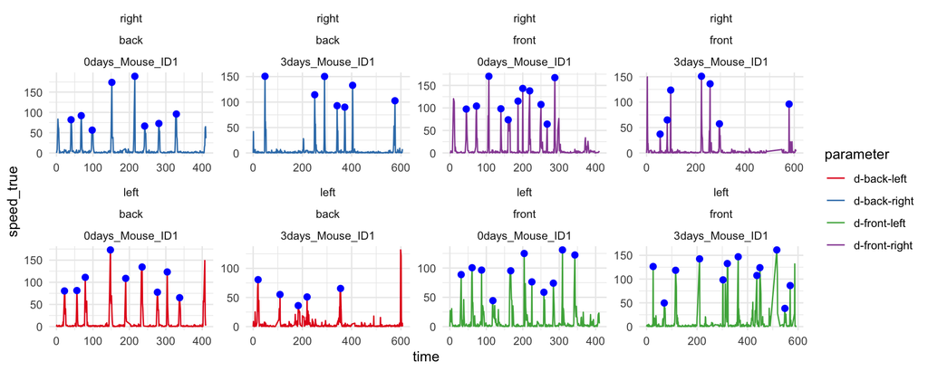

```r
# Divide dataset in front and back
pre_down_analysis <- long_data_clean2 %>% filter(side == "down") %>%
  mutate(limb = ifelse(parameter %in% c("d-front-left",
                                        "d-front-right",
                                        "d-head"), "front",
                       ifelse(parameter %in% c("d-back-left",
                                               "d-back-right",
                                               "d-tail-base"), "back", "none"))) %>%
  mutate(side = ifelse(parameter %in% c( "d-front-left",
                                         "d-back-left",
                                         "d-head", "d-tail-base"), "left",
                       ifelse(parameter %in% c("d-front-right",
                                               "d-back-right"), "right", "none")))


# Identify the speed of toe tips, this is a good indicator if the mouse is in a stance or swing position
Speed_down_pre <- pre_down_analysis %>%
  group_by(day, mouse, parameter, full_id) %>%
  mutate(speed = abs(x_corr- lag(x_corr, default = first(x_corr)))) %>% # calculate speed from pervious x_coor
  mutate(phase = ifelse(speed >12, NA, parameter)) %>% # Speed defined as 12 pixels/frame
  mutate(phase_names = ifelse(speed >7, "swing", "stance")) %>% # define swing and stance
  mutate(phase_numbers = cumsum(phase_names != lag(phase_names, default= first(phase_names)))) %>% # count phases
  group_by(full_id, phase_numbers) %>%
  mutate(Max_speed = max(speed))  %>% # max speed per phase number
  filter(Max_speed < 100) %>%   # max speed is in pixel per frames
  group_by(full_id) %>%
  mutate(Max_steps = max(phase_numbers)) %>%
  group_by(day, full_id, parameter, phase_numbers, phase_names) %>%
  mutate(Max_Time_in_phase = max(time)-min(time)) %>%
  mutate(day_Num = as.numeric(gsub("[^0-9.]", "",  day))) # Make new column with numeric day


# subset only toes and convert pixel per frames in cm/s
Speed_down <- Speed_down_pre %>%
   filter(parameter %in% c("d-front-left","d-front-right", "d-back-left","d-back-right")) %>%
   mutate(Max_speed_true = Max_speed/31.3667*60) %>% # convert pixel per frames in cm/s
   mutate(speed_true = speed/31.3667*60) %>%
  ungroup()


# the order is important here
Speed_down$side <- factor(Speed_down$side, levels =c("right", "left"))
Speed_down$limb <- factor(Speed_down$limb, levels =c("back", "front"))

limbcolors <- brewer.pal(4, "Set1")
mycolors3 <- colorRampPalette(brewer.pal(6, "Set2"))(6)


# We select individual videos and look how the speed determines a step cycle
Speed_down_select <- Speed_down %>% filter(full_id %in% c("0days_Mouse_ID1", "3days_Mouse_ID1"))

# Plot the walk profile from down as a function of speed. It is probably the best parameter so far to determine steps.
PLOT_Speed <- ggplot(Speed_down, aes(x=time, y = speed_true)) +
  geom_line(aes(color=parameter)) +
 facet_wrap(side~limb~full_id, scales = "free", ncol=4)+
  #geom_hline(yintercept=10)+
  theme(strip.text = element_text(size=15))+
  theme(legend.position = "none")+
  scale_color_manual(values=limbcolors)+
  scale_fill_manual(values=limbcolors)+
  stat_peaks(colour = "blue",  span = 21, strict = T, ignore_threshold = 0.2, size = 2) + # adapt to your set-up
  theme_minimal()

PLOT_Speed_exp <- ggplot(Speed_down_select, aes(x=time, y = speed_true)) +
  geom_line(aes(color=parameter)) +
 facet_wrap(side~limb~full_id, scales = "free", ncol=4)+
  #geom_hline(yintercept=10)+
  theme(strip.text = element_text(size=15))+
  theme(legend.position = "none")+
  scale_color_manual(values=limbcolors)+
  scale_fill_manual(values=limbcolors)+
  stat_peaks(colour = "blue",  span = 21, strict = T, ignore_threshold = 0.2, size = 2) + # adapt to your set-up
  theme_minimal()
PLOT_Speed_exp
```

(5.2) Extract the “Peaks” from PLOT_Speed to data frame in order to get information about steps

```r
info_steps_peak <-layer_data(PLOT_Speed, 2)
info_steps_peak <- select(info_steps_peak,x, PANEL)

# The only information from info_steps_peak that we have are the PANELs of the facet_wrap, therefore we need to reconstruct the information about right and left AND back and front:

nov <- max(as.numeric(info_steps_peak$PANEL)) # Panel = 4x Video_no

info_steps_peak$side <- ifelse(info_steps_peak$PANEL %in% c(seq(1,nov/2,1)), "right", "left")  # make sure the order is correct
info_steps_peak$limb <- ifelse(info_steps_peak$PANEL %in% c(seq(1,nov*1/4,1),seq(nov/2+1,nov*3/4,1)), "back", "front") # make sure the order is correct

# Transform the info_steps_peak into data.table for further analysis

info_steps_peak <- data.table(info_steps_peak)

# Count the steps for every valley, they always need to start at 1 for every PANEL
info_steps_peak <- info_steps_peak %>%
  group_by(PANEL) %>%
  mutate(steps = row_number())


# We need to make sure that PANEL represents the ID of df_vertical for the MERGE of data.tables:

info_steps_peak$CUT <- cut(as.numeric(info_steps_peak$PANEL), breaks=c(0,nov*1/4,nov*2/4,nov*3/4,nov*4/4), labels=c(0,nov*1/4,nov*2/4,nov*3/4))
info_steps_peak$CUT <- as.numeric(as.character(info_steps_peak$CUT))
info_steps_peak$PANEL <- as.numeric(as.character(info_steps_peak$PANEL))

info_steps_peak_2 <- mutate(info_steps_peak, ID = PANEL-CUT)
info_steps_peak_2$ID <- factor(info_steps_peak_2$ID)

info_steps_peak_2 <- data.table(info_steps_peak_2)
```

(5.3) Merge the generated information about steps with with the side perspective “vertical_df”

```r
vertical_df <- long_data_clean2 %>%
  filter(likelyhood > 0.95) %>%
  filter(side != "down") %>%
  mutate(limb = ifelse(parameter %in% c("l-wrist",
                                        "l-front-toe-tip",
                                        "l-elbow",
                                        "l-shoulder",
                                        "r-wrist",
                                        "r-front-toe-tip",
                                        "r-elbow",
                                        "r-shoulder", "l-head", "r-head"), "front",
                ifelse(parameter %in% c("l-back-ankle",
                                        "l-back-toe",
                                        "r-back-ankle",
                                        "r-back-toe", "l-hip", "r-hip", "l-iliac-crest", "r-iliac-crest", "l-tail-base", "r-tail-base"), "back", "none"))) %>%
  filter(side != "down") %>%
  arrange(full_id) %>%
  mutate(ID = cumsum(!duplicated(full_id)))

# make hip height  everywhere around 0
hip_norm <- vertical_df %>%
  filter(parameter %in% c("l-hip", "r-hip")) %>%
  select(side, full_id, time, y_corr) %>%
  group_by(side,full_id) %>%
  summarize(y_corr_hip = mean(y_corr))

toe_norm  <- vertical_df %>%
  filter(parameter %in% c("r-back-toe","l-back-toe", "r-front-toe-tip", "l-front-toe-tip")) %>%
  select(side, full_id, time, y_corr) %>%
  group_by(side,full_id) %>%
  summarize(y_corr_toe = median(y_corr))


vertical_df_norm <- vertical_df %>%
  full_join(hip_norm, by = c("full_id", "side")) %>%
  full_join(toe_norm, by = c("full_id", "side")) %>%
  mutate(y_norm_hip = y_corr- y_corr_hip ) %>%
  mutate(y_norm_toe = y_corr- y_corr_toe ) %>%
  mutate(ID = cumsum(!duplicated(full_id))) %>%
  filter(parameter %in% c("r-front-toe-tip", "l-front-toe-tip",  "r-back-toe", "l-back-toe", "l-hip", "r-hip", "l-shoulder", "r-shoulder","r-wrist", "l-wrist", "r-back-ankle", "l-back-ankle")) %>%
  select(-y_corr) %>% rename(y_corr = y_norm_toe)



vertical_df_norm$ID <- factor(vertical_df_norm$ID)



# We perform a  non-equi join to merge the data frames
vertical_df_steps <- info_steps_peak_2[vertical_df_norm,.(mouse, full_id, day, limb,side,i.time, x.x, x.steps, parameter, y_corr, x_corr),
                                          on=.(x <= time, side=side, limb =limb, ID=ID),  allow.cartesian=TRUE, mult ="last"]

# Add parameter_short, important for subsequent analysis
vertical_df_steps$parameter_short <- substr(vertical_df_steps$parameter, 3, nchar(as.character(vertical_df_steps$parameter)))
vertical_df_steps$side <- factor(vertical_df_steps$side, levels =c("right", "left"))
vertical_df_steps$limb <- factor(vertical_df_steps$limb, levels =c("back", "front"))

vertical_df_steps <- rename(vertical_df_steps, phase_numbers = x.steps)
vertical_df_steps <- rename(vertical_df_steps, time = i.time)

vertical_df_corr <- vertical_df_steps %>%
  group_by(full_id, side,limb, day ,parameter, parameter_short, phase_numbers) %>%
  summarize(y_corr_max = max(y_corr)) %>%
  filter(parameter_short %in% c("hip", "shoulder"))

vertical_df_steps_norm <- vertical_df_steps %>% left_join(vertical_df_corr, by = c("full_id", "side", "limb", "phase_numbers", "day")) %>%  # correction
  mutate(y_corr_norm = y_corr - y_corr_max) %>%
  select(-parameter_short.y, -parameter.y) %>%
  rename(parameter = parameter.x, parameter_short = parameter_short.x)
```

# (6) Look at typical profile from side perspective

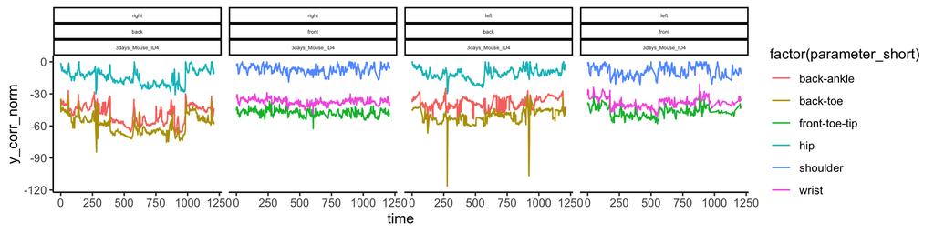

```r
# Plot the data, you should see a regular pattern and vertical lines determining the step cycle
validation_vertical_df_steps_test <- vertical_df_steps_norm %>% filter(parameter %in% c("r-wrist", "l-wrist",
                                                                                   "r-back-ankle", "l-back-ankle",
                                                                                   "l-back-toe", "r-back-toe",
                                                                                   "l-front-toe-tip", "r-front-toe-tip",
                                                                                   "l-shoulder", "r-shoulder",
                                                                                   "l-hip", "r-hip"))



validation_vertical_df_steps_test$side <- factor(validation_vertical_df_steps_test$side, levels =c("right", "left"))
validation_vertical_df_steps_test <- validation_vertical_df_steps_test %>% group_by(full_id, side, limb, phase_numbers) %>% mutate(x_time = min(time))

validation_vertical_df_steps_select <- validation_vertical_df_steps_test %>%
   filter(full_id %in% c("3days_Mouse_ID4"))


PLOT_validation_step_region <- ggplot(validation_vertical_df_steps_select, aes(x=time, y=y_corr_norm))+
  geom_line(aes(color=factor(parameter_short)))+
   facet_wrap(side~limb~full_id, ncol=4)+
  scale_x_continuous(limits = c(NA, NA))+
  scale_y_continuous(limits = c(NA, NA))+
  theme_classic()+
  theme(strip.text = element_text(size=4))
PLOT_validation_step_region
```

7. Overall error during ladder rung test

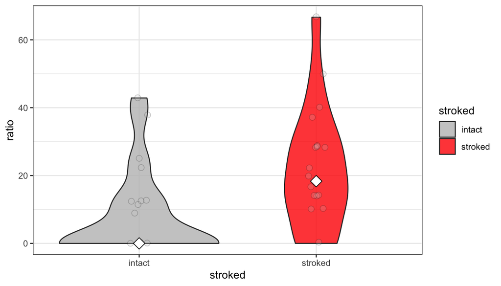

```r
summary_error_analysis <-  vertical_df_steps_norm %>%
  drop_na() %>%
  filter(parameter %in% c("r-front-toe-tip", "l-front-toe-tip",  "r-back-toe", "l-back-toe")) %>%
  group_by(full_id, side,limb, day ,parameter,phase_numbers) %>%
  summarize(y_corr_min = min(y_corr_norm)) %>%
mutate(ERROR2 = ifelse(y_corr_min < -65 &  limb =="back", "error", "ok")) %>% # correction factor
  mutate(ERROR = ifelse(y_corr_min < -57 & limb == "front", "error", ERROR2)) %>%
  mutate(all_steps = max(phase_numbers, na.rm = T)) %>%
  group_by(full_id, day, side, limb, parameter, all_steps) %>%
  summarise(success = sum(ERROR == "ok"), error = sum(ERROR == "error")) %>%
  mutate(ratio = error/all_steps*100)


summary_error_analysis_str_nonstr <- summary_error_analysis %>%
  filter(day %in% c("0days", "3days")) %>%
  mutate(stroked = ifelse(day == "0days", "intact", "stroked"))


mycolors <- c("grey", "red")

# Plot Error vs Non-Error
PLOT_Error_str_non_str<- ggplot(summary_error_analysis_str_nonstr, aes(stroked, ratio)) +
  geom_violin(aes(fill=stroked), trim = T, alpha = 0.8)+
   geom_jitter(aes(fill = stroked), width=0.05, alpha=0.2, pch=21,size=2.5, fill="lightgrey")+
   stat_summary(fun=median, geom="point", shape=23, size=4, color="black", fill ="white")+
  scale_y_continuous(limits = c(0, NA)) +
  scale_fill_manual(values=mycolors)+
  theme_bw()
PLOT_Error_str_non_str
```

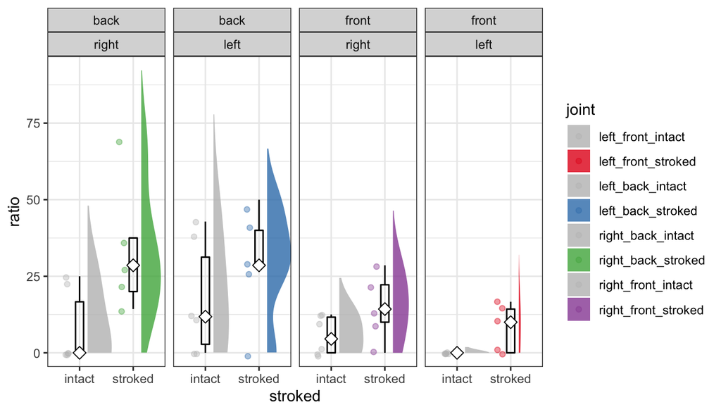

```r
summary_error_analysis_str_nonstr2 <- summary_error_analysis_str_nonstr %>%
  unite(joint, side, limb,stroked, sep = "_", remove = F) %>%
    mutate(joint = factor(joint, levels = c("left_front_intact", "left_front_stroked", "left_back_intact","left_back_stroked" , "right_back_intact", "right_back_stroked", "right_front_intact", "right_front_stroked")))


mycolors <- c("grey", "red")

limbcolors <- brewer.pal(4, "Set1")
limbcolors2 <- c("grey", "#E41A1C","grey", "#377EB8","grey", "#4DAF4A","grey", "#984EA3")


# Plot Overview
PLOT_HL_overview <- ggplot(summary_error_analysis_str_nonstr2, aes(x = stroked, y = ratio, fill = joint)) +
  geom_flat_violin(aes(fill = joint),position = position_nudge(x = .15, y = 0), adjust = 1.5, trim = FALSE, alpha = .8, colour = NA)+
  geom_boxplot(outlier.shape = NA, alpha = 0.3, width = .15, colour = "BLACK", fill = "NA",    position=position_dodge(10))+
  facet_wrap(limb~side, nrow=1)+
  geom_half_point(side = "l",   range_scale = .3, alpha = .4, aes(color=joint), position = position_nudge(x = -.02, y = 0),)+
  stat_summary(fun=median, geom="point", shape=23, size=3, color="black", fill ="white")+
  scale_y_continuous(limits = c(0, NA)) +
    scale_fill_manual(values=limbcolors2)+
    scale_color_manual(values=limbcolors2)+
  theme_bw()

PLOT_HL_overview
```

# (8) Time course of missteps

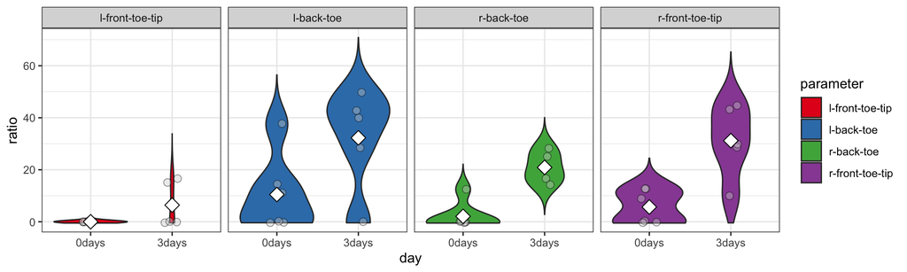

```r
# S
summary_error_analysis <-  vertical_df_steps %>%
  drop_na() %>%
  group_by(full_id, mouse, side,limb, day ,parameter,phase_numbers) %>%
  summarize(y_corr_min = min(y_corr)) %>%
  mutate(ERROR2 = ifelse(y_corr_min < -11 &  side =="left", "error", "ok")) %>%
  mutate(ERROR = ifelse(y_corr_min < -14 & side == "right", "error", ERROR2)) %>%
  mutate(all_steps = max(phase_numbers, na.rm = T))  %>%
  group_by(full_id, mouse, day, side, limb, parameter, all_steps) %>%
  summarise(success = sum(ERROR == "ok"), error = sum(ERROR == "error")) %>%
  mutate(ratio = error/all_steps*100)  %>%
  filter(parameter %in% c("r-front-toe-tip", "l-front-toe-tip",  "r-back-toe", "l-back-toe"))

# Exclude all with <4 steps and >20
summary_error_analysis2 <- summary_error_analysis %>%
  filter(all_steps>4) %>% filter(all_steps<15) %>%
  mutate(parameter = factor(parameter, levels = c("l-front-toe-tip", "l-back-toe", "r-back-toe", "r-front-toe-tip")))


summary_error_analysis3 <- summary_error_analysis2%>%
  filter(day %in% c("0days", "3days"))

limbcolors <- brewer.pal(4, "Set1")

PLOT_Error<- ggplot(summary_error_analysis3, aes(day, ratio)) +
  geom_violin(aes(fill = parameter), trim = F)+
   geom_jitter(width=0.1, alpha=0.4, pch=21,size=2.5, fill ="lightgrey")+
   stat_summary(fun=mean, geom="point", shape=23, size=4, color="black", fill ="white")+
  facet_wrap(.~parameter, nrow=1)+
  scale_y_continuous(limits = c(-0.5, NA)) +
 scale_color_manual(values=limbcolors)+
 scale_fill_manual(values=limbcolors)+
  theme_bw()
PLOT_Error
```

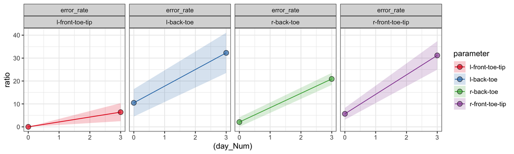

```r
summary_error_analysis$day_Num <- as.numeric(gsub("[^0-9.]", "",  summary_error_analysis$day))
summary_error_analysis2$day_Num <- as.numeric(gsub("[^0-9.]", "",  summary_error_analysis2$day))
summary_error_analysis2$pub = "error_rate"


limbcolors <- brewer.pal(4, "Set1")

PLOT_Error_line <- ggplot(summary_error_analysis2, aes(x=(day_Num), y = ratio))+
  stat_summary(aes(fill=parameter), geom="ribbon", fun.data = "mean_se",  alpha=0.2) +
  stat_summary(aes(color=parameter),fun=mean, geom="line") +
  stat_summary(aes(fill=parameter), fun=mean, geom="point", color = "black", shape=21, size =3, alpha = 0.7) +
 facet_wrap(pub~parameter, nrow=1)+
  scale_fill_manual(values=c(limbcolors))+
  scale_color_manual(values=c(limbcolors))+
  scale_y_continuous(limits = c(NA, NA))+
  theme_bw()
PLOT_Error_line
```

# (9) Summary all plots

```r
 # ggsave("Output_LadderRung_Analysis/Output_LadderRung_Figures/1_PLOT_bar_all_videos.pdf", PLOT_bar_all_videos, width=4, height=2.5)
 # ggsave("Output_LadderRung_Analysis/Output_LadderRung_Figures/2_PLOT_Donut_Summary_Validation.pdf", PLOT_Donut_Summary_Validation, width=10, height=3)
 # ggsave("Output_LadderRung_Analysis/Output_LadderRung_Figures/3_1_PLOT_control_for_outliers_before.pdf", PLOT_control_for_outliers_before, width=5, height=4)
 # ggsave("Output_LadderRung_Analysis/Output_LadderRung_Figures/3_2_PLOT_control_for_outliers_after.pdf", PLOT_control_for_outliers_after, width=5, height=4)
 # ggsave("Output_LadderRung_Analysis/Output_LadderRung_Figures/4_1_PLOT_Overview_Distribution_X.pdf", PLOT_Overview_Distribution_X, width=8, height=8)
 # ggsave("Output_LadderRung_Analysis/Output_LadderRung_Figures/4_2_PLOT_Overview_Distribution_Y.pdf", PLOT_Overview_Distribution_Y, width=8, height=8)
 # ggsave("Output_LadderRung_Analysis/Output_LadderRung_Figures/5_PLOT_overview_steps.pdf", PLOT_overview_steps, width=12, height=8)
 # ggsave("Output_LadderRung_Analysis/Output_LadderRung_Figures/5_1_PLOT_Speed.pdf", PLOT_Speed, width=13, height=5)
 # ggsave("Output_LadderRung_Analysis/Output_LadderRung_Figures/6_PLOT_validation_step_region.pdf", PLOT_validation_step_region, width=8, height=3)
 # ggsave("Output_LadderRung_Analysis/Output_LadderRung_Figures/7_1_PLOT_Overall_errror_rate.pdf", PLOT_Error_str_non_str, width=4.2, height=2.5, limitsize =F)
 # ggsave("Output_LadderRung_Analysis/Output_LadderRung_Figures/7_2_PLOT_horizontal_ladder_overview.pdf", PLOT_HL_overview, width = 7, height = 2.5)
 # ggsave("Output_LadderRung_Analysis/Output_LadderRung_Figures/7_3_Error_rate_violin.pdf", PLOT_Error, width = 8, height = 3)
 # ggsave("Output_LadderRung_Analysis/Output_LadderRung_Figures/7_4_Error_rate_line.pdf", PLOT_Error_line, width = 6.8, height =2.5)
```

# (10) Summmary of raw files

```r
# Generate raw and summarized data
raw_files <- summary_error_analysis_str_nonstr2
glimpse(raw_files)
```

```
## Rows: 44
## Columns: 11
## Groups: full_id, day, side, limb, parameter [44]
## $ full_id   <fct> 0days_Mouse_ID1, 0days_Mouse_ID1, 0days_Mouse_ID1, 0days_Mou…
## $ day       <fct> 0days, 0days, 0days, 0days, 0days, 0days, 0days, 0days, 0day…
## $ joint     <fct> right_back_intact, right_front_intact, left_back_intact, lef…
## $ side      <fct> right, right, left, left, right, right, left, left, right, r…
## $ limb      <fct> back, front, back, front, back, front, back, front, back, fr…
## $ parameter <chr> "r-back-toe", "r-front-toe-tip", "l-back-toe", "l-front-toe-…
## $ all_steps <int> 8, 11, 9, 11, 8, 8, 8, 8, 8, 8, 7, 9, 6, 10, 9, 10, 9, 11, 8…
## $ success   <int> 8, 10, 9, 11, 8, 7, 5, 8, 6, 7, 4, 9, 6, 10, 8, 10, 7, 11, 7…
## $ error     <int> 0, 1, 0, 0, 0, 1, 3, 0, 2, 1, 3, 0, 0, 0, 1, 0, 2, 0, 1, 0, …
## $ ratio     <dbl> 0.000000, 9.090909, 0.000000, 0.000000, 0.000000, 12.500000,…
## $ stroked   <chr> "intact", "intact", "intact", "intact", "intact", "intact", …
```

```r
sum_overview_day <- summary_error_analysis2 %>%
  group_by(parameter, day) %>%
  summarize(median = median(ratio), mean = mean(ratio), sd = sd(ratio))
glimpse(sum_overview_day)
```

```
## Rows: 8
## Columns: 5
## Groups: parameter [4]
## $ parameter <fct> l-front-toe-tip, l-front-toe-tip, l-back-toe, l-back-toe, r-…
## $ day       <fct> 0days, 3days, 0days, 3days, 0days, 3days, 0days, 3days
## $ median    <dbl> 0.000000, 0.000000, 5.555556, 40.000000, 0.000000, 20.000000…
## $ mean      <dbl> 0.000000, 6.410256, 10.482804, 32.285714, 2.083333, 20.90476…
## $ sd        <dbl> 0.000000, 8.789301, 14.659149, 19.629216, 5.103104, 5.876661…
```

```r
# Export all .csv files

#write.csv(raw_files, "Output_LadderRung_Analysis/Output_LadderRung_csv/raw_values.csv")
#write.csv(sum_overview_day, "Output_LadderRung_Analysis/Output_LadderRung_csv/summary_values.csv")
```